# Rebalancing Drift — SPY/IEF 60/40

# 6 Pairwise Comparisons: Each Strategy vs Buy & Hold

Each figure below isolates one strategy against the Buy & Hold baseline. The drift panels (right column) now measure **strategy − BaH** rather than strategy − daily rebal.

**Positive drift** = strategy beats BaH on that day. **Negative drift** = BaH beats strategy on that day.

## 6.1 Daily Rebal vs Buy & Hold

Daily rebalancing always enters Falls at exactly 60% equity — the minimum possible overweight relative to BaH. The SPY weight panel (D6) shows a **flat line** at 60%: the portfolio has no drift by construction.

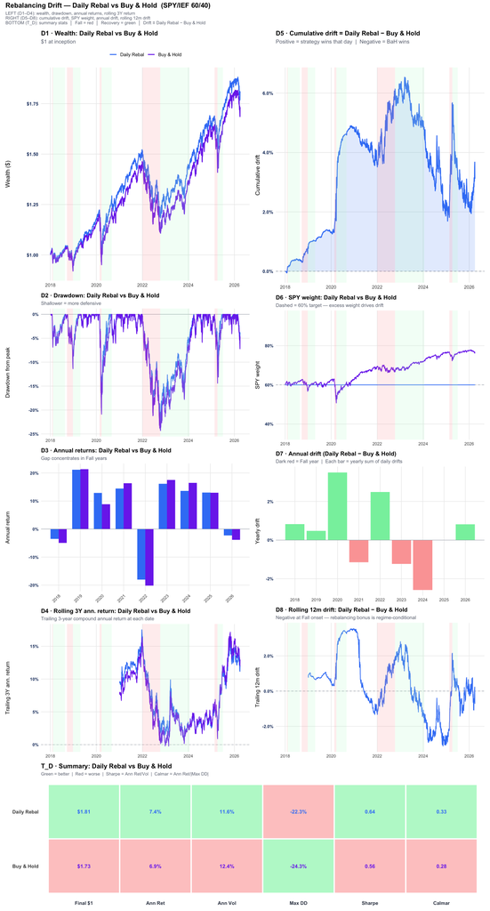

## 6.2 Quarterly Rebal vs Buy & Hold

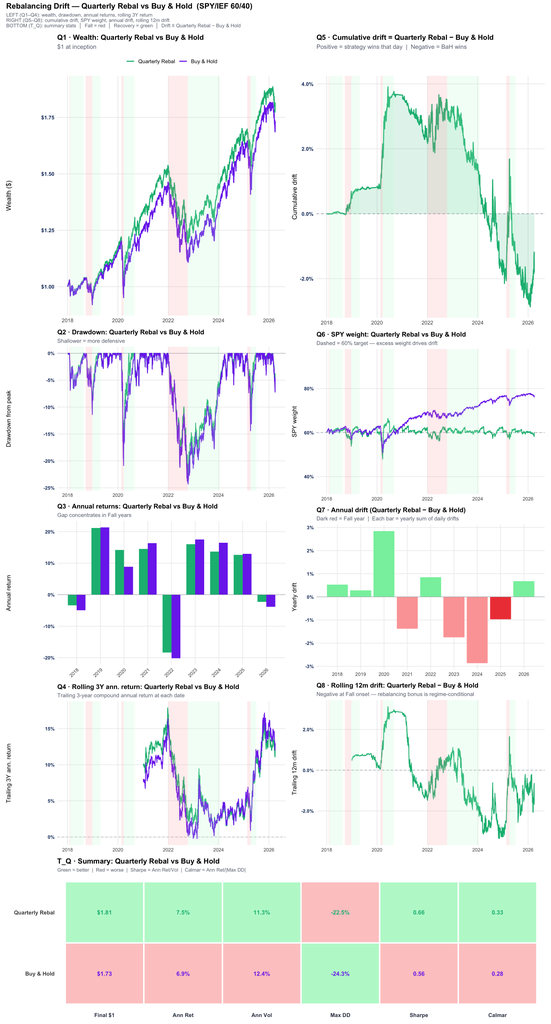

## 6.3 Annual Rebal vs Buy & Hold

Annual rebalancing resets once per year on 1 January. If a Fall occurs late in the year the portfolio may have drifted significantly before the reset. The SPY weight panel (AR6) shows the characteristic sawtooth: drift builds through the year, snaps back at year-end.

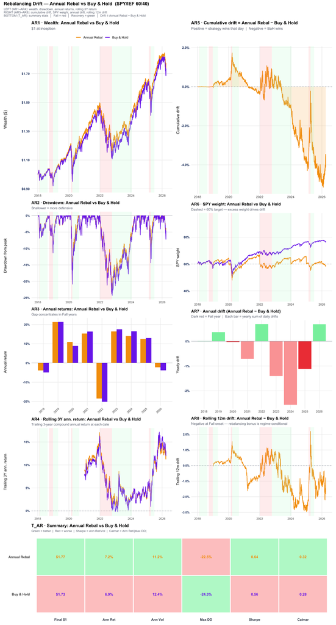

## 6.4 Threshold Rebal ±10% vs Buy & Hold

Threshold rebalancing is **event-driven**: rebalance only when SPY weight drifts outside [50%, 70%]. Unlike calendar strategies, it rebalances more during volatile periods (when the bonus is largest) and less during calm trends (letting momentum run). This is implicitly **regime-aware** without knowing the regime.

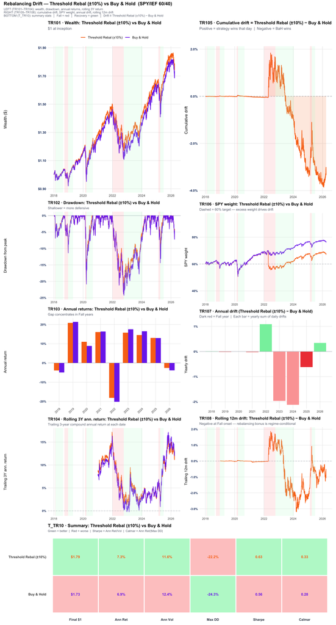

## 6.5 Threshold Rebal ±5% vs Buy & Hold

A tighter ±5% band [55%, 65%] triggers rebalancing more frequently. It is closer to daily rebalancing in behaviour during volatile periods and still captures some momentum during calm trends. Compare TR5 and TR10 SPY weight panels to see how the band width controls the degree of drift allowed.

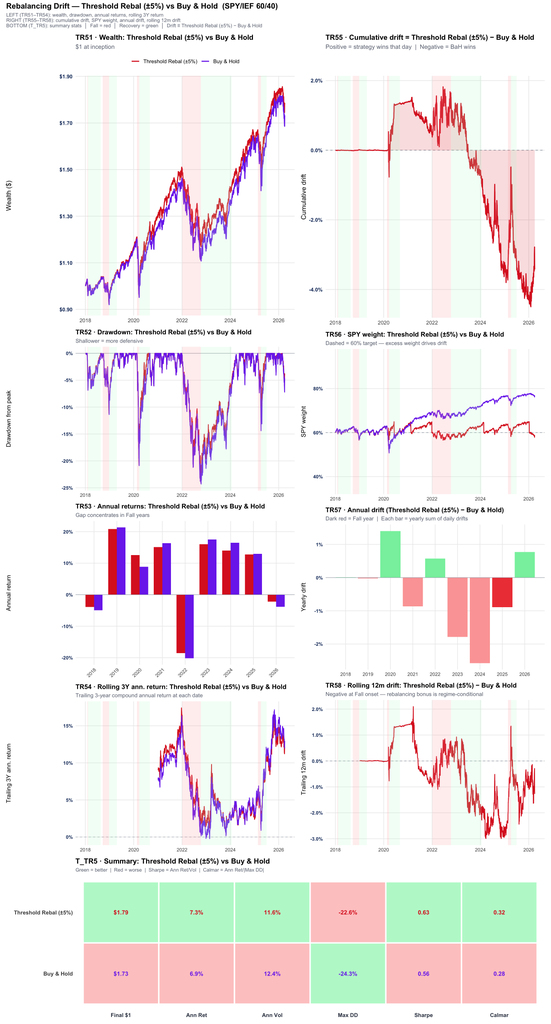